# データ解析論II第10講

## 目次

## 分類

## 分類について

- p286「第12章 似た者同士にグループ分けしたい–クラスター分析」

## 分類とは

- あるデータから対象を区別すること
  - ex.出身地域（質的変数）から人を区別することは可能だが，身長・体重など（量的変数）から区別することは難しい．

## 階層クラスタリングと非階層クラスタリング

- 階層クラスタリング：段階的に分割or結合を繰り返しながらクラスターを形成する．
- 非階層クラスタリング：一斉に対象を分割してクラスターを形成する．

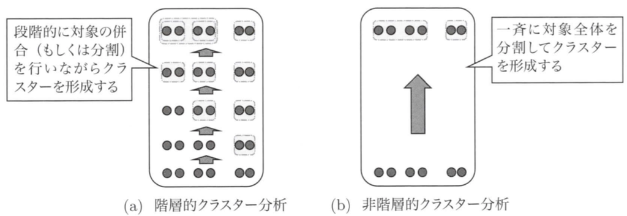

## 階層クラスタリングと非階層クラスタリングの手順

- 階層クラスタリング：段階的に分割or結合を繰り返しながらクラスターを形成する．
1. 非類似度行列の算出
2. デンドログラムの作成
3. クラスター数の決定
4. クラスター数の妥当性の確認
5. クラスターの特徴の考察

## 階層クラスタリングと非階層クラスタリングの手順

- 非階層クラスタリング：一斉に対象を分割してクラスターを形成する．
1. クラスター数の決定
2. クラスター数の決定
3. クラスター数の妥当性の確認
4. クラスターの特徴の考察

## 階層的クラスター分析

## クラスター分析をやってみよう

- [データ](https://www.dropbox.com/sh/ddpegx63wsdsbel/AACIJbIhY0YtbrLPSgR7xqFTa?dl=0)
- データの読み込み：日本語が混ざっているので，RStudioに読みこませる→“from global workspace”から読み込み
  - RStudioに読み込ませるときには画像の通りのプロセスを行う

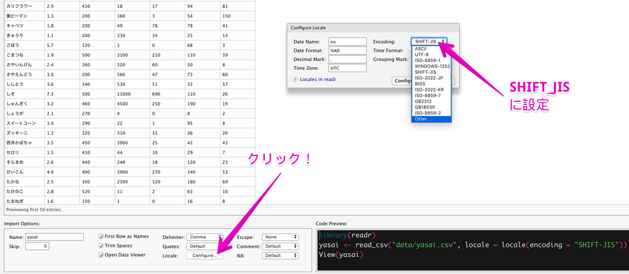

```r
library(readr)
yasai <- read_csv("../data/yasai.csv",
    locale = locale(encoding = "SHIFT-JIS"))
```

## データ分析の目的

- 6つの野菜の要素に基づいて，栄養素が似た者同士をグループ化する．
  - クラスター：同じ種類の人やモノの集合のこと

## 野菜の名前だけを取り出したい

```r
yasai_name <- yasai %>%
  select(X1)
```

## 非類似度行列の作成

```r
DO <- dist(yasai, method="euclidean")
D <- (1/2)*DO^2
```

## デンドログラム作成の下処理

```r
ysi.out<-hclust(d=D,method="ward.D")
```

## デンドログラム作成

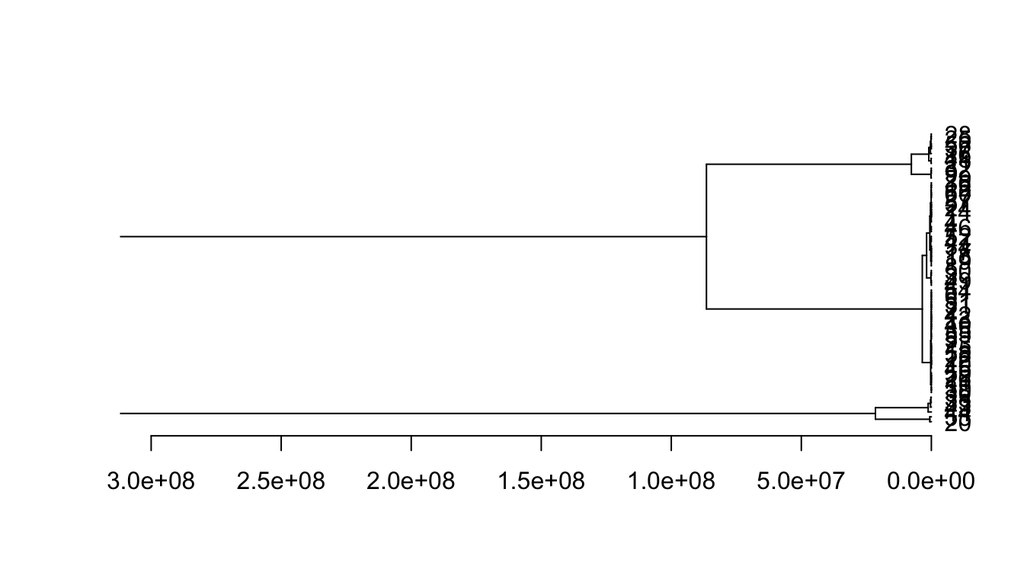

```r
plot(as.dendrogram(ysi.out), xlim = c(300000000,0), horiz=T)
```

- だいたい似た者同士がグループになっている．
- 細かく項目について評価してみましょう．

## 各クラスターの特徴の把握

```r
clusterH <- factor(cutree(ysi.out, k=3))
```

## 野菜の名前とクラスターをくっつける

```r
yasai_cluster <- cbind(yasai, clusterH)
```

## 各クラスターの平均

```r
yasai_cluster %>%
group_by(clusterH) %>%
summarise(食物繊維=round(mean(食物繊維, na.rm = T, digits=3), 3),
    カリウム=round(mean(カリウム, na.rm = T, digits=3), 3),
    ベータカロテン=round(mean(ベータカロテン, na.rm = T, digits=3), 3),
    ビタミンK=round(mean(ビタミンK, na.rm = T, digits=3), 3),
    葉酸=round(mean(葉酸, na.rm = T, digits=3), 3),
    ビタミンC=round(mean(ビタミンC, na.rm = T, digits=3), 3))
```

```
## # A tibble: 3 x 7
##   clusterH 食物繊維 カリウム ベータカロテン ビタミンK  葉酸 ビタミンC
##   <fct>       <dbl>    <dbl>          <dbl>     <dbl> <dbl>     <dbl>
## 1 1            2.97     304.           280.      31.5  74.5      35.2
## 2 2            2.63     415.          3290      182.  130.       41.4
## 3 3            6.18     585           8033.     444   118.       58.8
```

## 野菜のクラスターを確認

```r
library(DT)
datatable(
  yasai_cluster
)
```

|  | X1 | 食物繊維 | カリウム | ベータカロテン | ビタミンK | 葉酸 | ビタミンC | clusterH |
| --- | --- | --- | --- | --- | --- | --- | --- | --- |
| 1 | 青ピーマン | 2.3 | 190 | 400 | 20 | 26 | 76 | 1 |
| 2 | 赤たまねぎ | 1.7 | 150 | 0 | 0 | 23 | 7 | 1 |
| 3 | 赤ピーマン | 1.6 | 210 | 940 | 7 | 68 | 170 | 1 |
| 4 | アスパラガス | 1.8 | 270 | 370 | 43 | 190 | 15 | 1 |
| 5 | アロエ | 0.4 | 43 | 1 | 0 | 4 | 1 | 1 |
| 6 | うど | 1.4 | 220 | 0 | 2 | 19 | 4 | 1 |
| 7 | えだまめ | 5 | 590 | 240 | 30 | 320 | 27 | 1 |
| 8 | オクラ | 5 | 260 | 670 | 71 | 110 | 11 | 1 |
| 9 | かいわれだいこん | 1.9 | 99 | 1900 | 200 | 96 | 47 | 2 |
| 10 | かぶ | 1.5 | 280 | 0 | 0 | 48 | 19 | 1 |

[output cut: 50 more lines]

## z得点化による分析

- ここではわかりやすいように素点のまま実施したが，データによって平均や分散が異なるために，z得点化（標準化）して分析した方が良い

```r
yasai_noname <- yasai %>%
  select(-X1)
yasai_z <- scale(yasai_noname)
DO_z <- dist(yasai_z, method = "euclidean")
D_z <- (1/2)*DO_z^2
yasai_z.out <- hclust(d=D_z, method="ward.D")
```

## デンドログラム作成

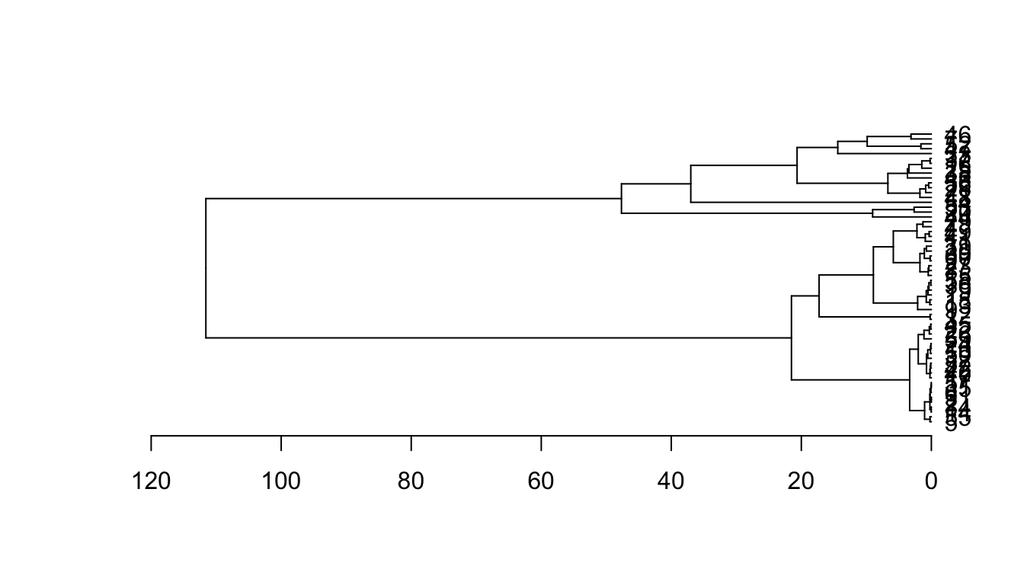

```r
plot(as.dendrogram(yasai_z.out), xlim = c(120,0), horiz=T)
```

- だいたい似た者同士がグループになっている．
- 細かく項目について評価してみましょう．

## 各クラスターの特徴の把握

```r
cluster_z <- factor(cutree(yasai_z.out, k=3))
```

## 野菜の名前とクラスターをくっつける

```r
yasai_cluster_z <- cbind(yasai_cluster, cluster_z)
```

## 各クラスターの平均

```r
yasai_cluster_z %>%
group_by(cluster_z) %>%
summarise(食物繊維=round(mean(食物繊維, na.rm = T, digits=3), 3),
    カリウム=round(mean(カリウム, na.rm = T, digits=3), 3),
    ベータカロテン=round(mean(ベータカロテン, na.rm = T, digits=3), 3),
    ビタミンK=round(mean(ビタミンK, na.rm = T, digits=3), 3),
    葉酸=round(mean(葉酸, na.rm = T, digits=3), 3),
    ビタミンC=round(mean(ビタミンC, na.rm = T, digits=3), 3))
```

```
## # A tibble: 3 x 7
##   cluster_z 食物繊維 カリウム ベータカロテン ビタミンK  葉酸 ビタミンC
##   <fct>        <dbl>    <dbl>          <dbl>     <dbl> <dbl>     <dbl>
## 1 1             2.25     274.           390.      32.3  63.4      32.1
## 2 2             5.32     500           3243.     155.  137.       50.7
## 3 3             6.67     677.          9467.     727.  193.       70.3
```

## 野菜のクラスターを確認

```r
library(DT)
datatable(
  yasai_cluster_z
)
```

|  | X1 | 食物繊維 | カリウム | ベータカロテン | ビタミンK | 葉酸 | ビタミンC | clusterH | cluster_z |
| --- | --- | --- | --- | --- | --- | --- | --- | --- | --- |
| 1 | 青ピーマン | 2.3 | 190 | 400 | 20 | 26 | 76 | 1 | 1 |
| 2 | 赤たまねぎ | 1.7 | 150 | 0 | 0 | 23 | 7 | 1 | 1 |
| 3 | 赤ピーマン | 1.6 | 210 | 940 | 7 | 68 | 170 | 1 | 1 |
| 4 | アスパラガス | 1.8 | 270 | 370 | 43 | 190 | 15 | 1 | 1 |
| 5 | アロエ | 0.4 | 43 | 1 | 0 | 4 | 1 | 1 | 1 |
| 6 | うど | 1.4 | 220 | 0 | 2 | 19 | 4 | 1 | 1 |
| 7 | えだまめ | 5 | 590 | 240 | 30 | 320 | 27 | 1 | 2 |
| 8 | オクラ | 5 | 260 | 670 | 71 | 110 | 11 | 1 | 1 |
| 9 | かいわれだいこん | 1.9 | 99 | 1900 | 200 | 96 | 47 | 2 | 1 |
| 10 | かぶ | 1.5 | 280 | 0 | 0 | 48 | 19 | 1 | 1 |

[output cut: 50 more lines]

## 非階層的クラスター分析

## k-meansクラスター分析

- K-meansクラスタリング：データをk個に分類する手法
  - クラスターの平均を用いて，うまい具合にデータが分類できるように調整させていくアルゴリズム．
  - 任意のk個に分類するアルゴリズムであることからk-meansと呼ばれる．
- 参考：[リンク](https://qiita.com/Haruka-Ogawa/items/fcda36cc9060ba851225)

## クラスター数の妥当性の検討

- 実はかなり難しい．
  - 多すぎてもいけないし，少なすぎてもいけないから難しい．
- Gap統計量を用いたクラスタ数の決定：クラスタ数に応じて，一様分布に基づいて作成されたクラスタ内の距離の平均値と，元データのクラスタ内の距離の平均値を比較し、密集しているクラスタ数を選ぶ．

## クラスター数の妥当性の検討

```r
library(cluster)
result <- clusGap(yasai_noname, kmeans,
                  K.max = 5, B = 100,
                  verbose = interactive())
```

- sample：データ
- kmenas：K-means法
- K.max：クラスタ数の最大値
- B：モンテカルロ法のブートストラップ回数
- verborse：処理状況を表示するかどうか

## 結果の可視化

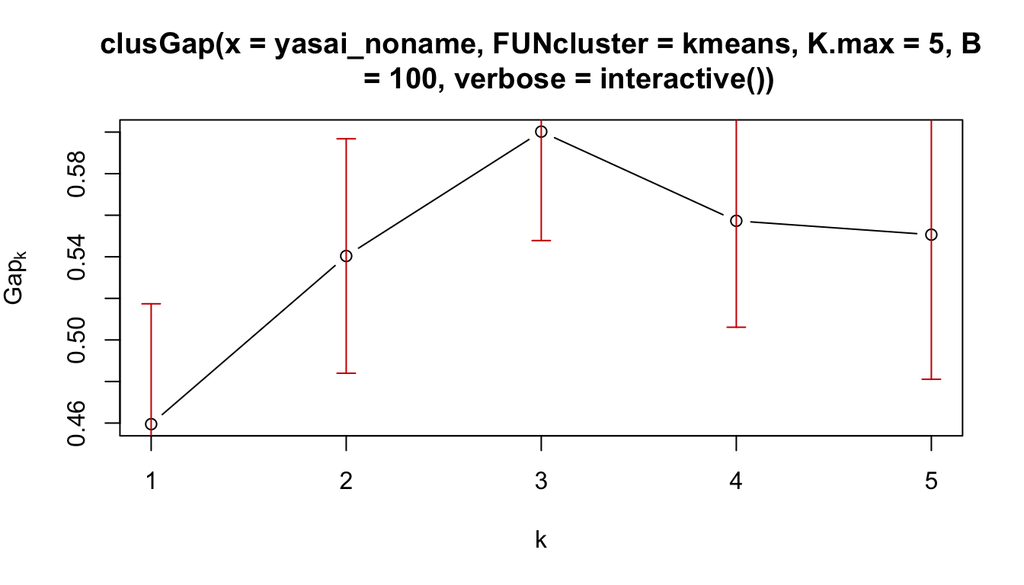

```r
plot(result)
```

## クラスター分析の実施

```r
kmeans_cluster3 <- kmeans(yasai_noname, 3)
```

## 色々くっつくける（野菜データと名前とk-meansと）

```r
yasai_cluster_z<-cbind(yasai_cluster_z,
                       kmeans_cluster3$cluster)
```

## 各クラスターの平均

```r
yasai_cluster_z %>%
group_by(cluster_z) %>%
summarise(食物繊維=round(mean(食物繊維, na.rm = T, digits=3), 3),
    カリウム=round(mean(カリウム, na.rm = T, digits=3), 3),
    ベータカロテン=round(mean(ベータカロテン, na.rm = T, digits=3), 3),
    ビタミンK=round(mean(ビタミンK, na.rm = T, digits=3), 3),
    葉酸=round(mean(葉酸, na.rm = T, digits=3), 3),
    ビタミンC=round(mean(ビタミンC, na.rm = T, digits=3), 3))
```

```
## # A tibble: 3 x 7
##   cluster_z 食物繊維 カリウム ベータカロテン ビタミンK  葉酸 ビタミンC
##   <fct>        <dbl>    <dbl>          <dbl>     <dbl> <dbl>     <dbl>
## 1 1             2.25     274.           390.      32.3  63.4      32.1
## 2 2             5.32     500           3243.     155.  137.       50.7
## 3 3             6.67     677.          9467.     727.  193.       70.3
```

## 野菜のクラスターを確認

```r
library(DT)
datatable(
  yasai_cluster_z
)
```

|  | X1 | 食物繊維 | カリウム | ベータカロテン | ビタミンK | 葉酸 | ビタミンC | clusterH | cluster_z | kmeans_cluster3$cluster |
| --- | --- | --- | --- | --- | --- | --- | --- | --- | --- | --- |
| 1 | 青ピーマン | 2.3 | 190 | 400 | 20 | 26 | 76 | 1 | 1 | 2 |
| 2 | 赤たまねぎ | 1.7 | 150 | 0 | 0 | 23 | 7 | 1 | 1 | 2 |
| 3 | 赤ピーマン | 1.6 | 210 | 940 | 7 | 68 | 170 | 1 | 1 | 2 |
| 4 | アスパラガス | 1.8 | 270 | 370 | 43 | 190 | 15 | 1 | 1 | 2 |
| 5 | アロエ | 0.4 | 43 | 1 | 0 | 4 | 1 | 1 | 1 | 2 |
| 6 | うど | 1.4 | 220 | 0 | 2 | 19 | 4 | 1 | 1 | 2 |
| 7 | えだまめ | 5 | 590 | 240 | 30 | 320 | 27 | 1 | 2 | 2 |
| 8 | オクラ | 5 | 260 | 670 | 71 | 110 | 11 | 1 | 1 | 2 |
| 9 | かいわれだいこん | 1.9 | 99 | 1900 | 200 | 96 | 47 | 2 | 1 | 1 |
| 10 | かぶ | 1.5 | 280 | 0 | 0 | 48 | 19 | 1 | 1 | 2 |

[output cut: 50 more lines]

## 演習問題

## 教科書p315章末問題

- これの問1-5までに挑戦してみましょう．
- ただし，出来たところまでで構いません．

## ランダム比較化実験とは

## 因果推論とは：

- 因果推論：原因と結果の関係，因果関係を明らかにするための手法
- いわゆる回帰分析やロジスティック回帰分析でやってきたことは「相関関係」を明らかにするのであって，因果関係はわからない．
  - でも，ホントは因果関係を知りたいことが多い．
- 因果関係を明らかにするには「実験」が採用の手段
  - 世の中実験ができれば最高！
  - しかし，必ずしも実験ができないこともたくさんある．．．

## RCT：

- ランダム化比較実験：「介入」の効果を適切に分析する手法であり，実験群と操作群に分けて影響を検討する方法
- - [参考](https://www.rieti.go.jp/jp/columns/s18_0009.html)
  - 実験的な介入ができれば良いけど，できないことも多い．